# lep-MAP3-varroa

Nurit Eliash

2022-07-05

## Load libraries

```r
library("tidyverse")
library("plyr")
```

```r
library("dplyr")
library("ggplot2")
library("scales")
library("ggpubr")
library("gridExtra") # for arranging a few plots in one area
#library("grid")
#library("GGally")
library("data.table")
library("stringr")
library("janitor")
library("plotly") # to identify outliers.
library("readr") # to extract numbers from a vector
library("tidyr")
library("LinkageMapView") # for constructing the linkage map
library("vcfR") # for extracting genotype data from a vcf file
knitr::opts_chunk$set(include = FALSE)
```

## Load Variant Call Format (VCF) file.

Extract genotypes for each site and individual. The metadata for all samples can be found in [here](https://github.com/nurit-eliash/varroa-linkage-map/blob/main/data/meta_data_223.xlsx).

We used the VCF file in two methods to estimate varroa mite recombination frequency:  
- **Lep-MAP3, a linkage mapping software (Rastas 2017).**  
- **Manual estimation of the recombination rate**, R script can be found in the file manually-estimating-recom.Rmd

# Estimating recombination frequency using Lep-MAP3

We followed the documentation in the [Lep-MAP3 Wiki page](https://sourceforge.net/p/lep-map3/wiki/LM3%20Home/), with a few adjustments (See Fig 1).

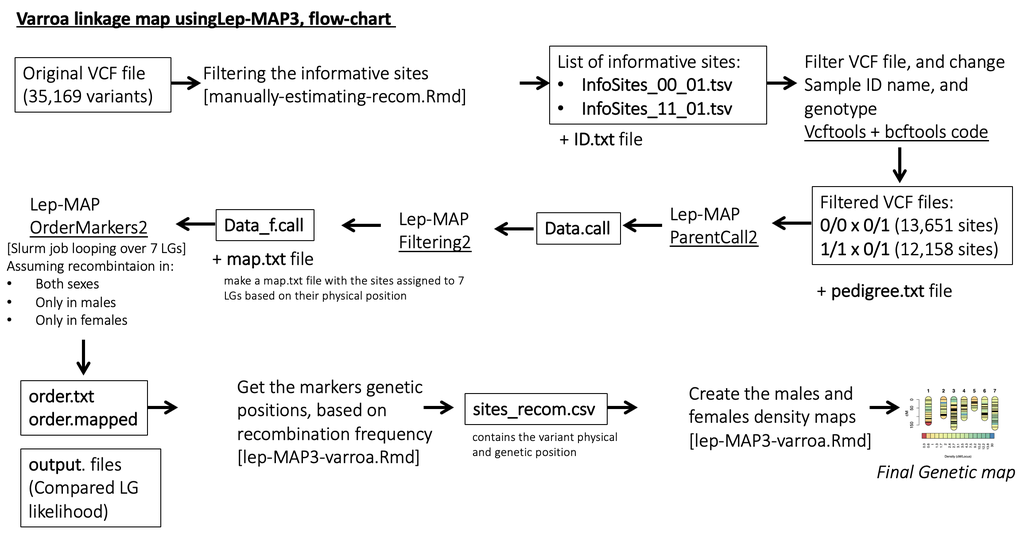

We ran the first two modules: **ParentCall2**, **Filtering2**, then skipped to the last module **OrderMarkers2** that produces the final map file.  
The input and output files for each modules are as follow:  
(1) **ParentCall2** module; options = removNonInformative; input = filtered VCF file and pedigree.txt; output = data.call.  
(2) **Filtering2** module; options = dataTolerance=0.0001, removeNonInformative; input = data.call; output = data_f.call. (3) **OrderMarkers2** module; options = useKosambi=1 numMergeIterations=100 sexAveraged=1 outputPhasedData=2 grandparentPhase=1; input = data_f.call and map.txt files; output = order.txt and order.mapped files.

In the following codes we generated two files necessary for the Lep-MAP analysis:  
- the list of informative sites (used to filter the original VCF file), for the first module, **ParentCall2**; - and the map.txt file, containing the physical position of sites, for the last module, **OrderMarkers2**.

**Keep:**

- Informative sites.
- 121 adult mite samples.

**Change:**

- Sample ID name (F0, F1_fem, and F1_male)
- site genotype for the above 3 samples, as per the cross:

**For 0/0 x 0/1 cross:**  
F1_fem = 0/1:22:10,12:10:353:12:444:-33.6837,0,-25.484  
F1_male = 0/0:17:17,0:17:565:0:0:0,-5.11751,-51.1547  
F0 = 0/0:17:17,0:17:565:0:0:0,-5.11751,-51.1547

**For 1/1 x 0/1 cross:**  
F1_fem = 0/1:22:10,12:10:353:12:444:-33.6837,0,-25.484  
F1_male = 1/1:17:0,17:0:0:17:629:-56.9466,-5.11751,0  
F0 = 1/1:17:0,17:0:0:17:629:-56.9466,-5.11751,0

Code for changing sample genotype, see this [bash script](https://github.com/nurit-eliash/varroa-linkage-map/blob/main/data/formatVCF.sh)

## (1) Keep informative sites:

filter for informative sites in the original VCF file.

### cross (0/0 x 0/1)

in each family, filter for sites with:  
(a) homo x hetero F1 cross (0/0 x 0/1), so we can predict the parental and recombinant F2 types.  
(b) homo F0 (0/0), so we can phase the hetero F1 sites.

There are 13,651 informative sites for the 0/0 x 0/1 F1 “family”.  
Save the file as tsv, so it can be used in the next steps.

```r
#write_delim(InfoSites_00_01, "/Users/nuriteliash/Documents/GitHub/varroa-linkage-map/results/InfoSites_00_01.tsv", col_names = FALSE)

# check manually a few IDs and sites,
#InfoSites_00_01 <- reduce(sites, bind_rows) %>% as.data.frame() %>% distinct(site, .keep_all = TRUE)

#tableInfo = InfoSites_00_01 %>% select(c(site,`57_58b_grnson`))
#tableAll = df %>% select(c(site,`57_58b_grnson`))
#left_join(tableInfo, tableAll, by = "site") %>% rename(c("57_58b_grnson.x" ="InfoSites", "57_58b_grnson.y" = "AllSites")) %>% view()
```

### cross (1/1 x 0/1)

There are 12,158 informative sites for the 1/1 x 0/1 F1 “family”  
Save the file as tsv, so it can be used in the next steps.

```r
#write_delim(InfoSites_11_01, "/Users/nuriteliash/Documents/GitHub/varroa-linkage-map/results/InfoSites_11_01.tsv", col_names = FALSE)

# check manually a few IDs and sites,
#InfoSites_11_01 <- reduce(sites, bind_rows) %>% as.data.frame() %>% distinct(site, .keep_all = TRUE)

#tableInfo = InfoSites_11_01 %>% select(c(site,`300_301a_grnson`))
#tableAll = df %>% select(c(site,`300_301a_grnson`))
#check <- left_join(tableInfo, tableAll, by = "site") %>% rename(c("300_301a_grnson.x" ="InfoSites", "300_301a_grnson.y" = "AllSites")) %>% na.omit("InfoSites")

#all(check$InfoSites == check$AllSites)
```

## (2) Create a map.txt file with sites’ physical position, for the OrderMarkers2 module

make a map.txt file with the sites assigned to 7 LGs based on their physical position use this file as an input for the Order module.

the ordering doesn’t have to be fantastic either at the end. We’re just looking to see if we can get some sort of recombination rate estimates and a sense of which sex is showing recombination.

### cross (0/0 x 0/1)

### cross (1/1 x 0/1)

the map.txt files are used along with the Data_f.call (generated by the **Filtering2** module) will be used as input for the final module, **OrderMarkers2** module.

# 0/0 x 0/1 cross

## Assuming recombintaions in males and females

## Assuming recombinations in *FEMALES ONLY*

## Assuming recombintaions in *MALES only*

# 1/1 x 0/1 cross

## Assuming recombintaions in males and females

## Assuming recombinations in *FEMALES ONLY*

## Assuming recombintaions in *MALES only*

### Markers positions, assuming recombinations in *both sexes*